# Tamanho mínimo de amostra

```r
library(dplyr)
library(readxl)
library(knitr)
library(ggplot2)
library(ggridges)
library(reshape2)
library(gridExtra)
library(vtable)
```

```r
my_theme <- theme_minimal(base_size = 11) +
  theme(
    axis.text = element_text(size = 8),
    plot.title = element_text(hjust = 0.5, size = 12),
    axis.title = element_text(size = 10),
    panel.grid.major = element_line(colour = "grey90", linewidth = 0.5),
    panel.grid.minor = element_line(colour = adjustcolor("grey90", alpha.f = 0.5), linewidth = 0.25),
    panel.border = element_blank(),
    panel.background = element_blank(),
    plot.background = element_blank(),
    axis.line.x = element_line(colour = "grey"),
    axis.line.y = element_line(colour = "grey"),
  )

no_legend <- my_theme + theme(legend.position = "none")

no_grid <- my_theme + theme(
  panel.grid.major = element_blank(),
  panel.grid.minor = element_blank()
)

no_axis <- my_theme + theme(
  axis.line.x = element_blank(),
  axis.line.y = element_blank()
)
```

## Objetivo

Estimar a quantidade total de leads mensais, com 80% de confiança, por anunciante, de anúncios de vendas de imóveis na cidade de Florianópolis (SC).

*Lead*: é um contato de um cliente em potencial que demonstrou interesse em um produto ou serviço.

IC de 80% foi escolhido devido à falta de informações (descrita logo mais), e também por ser este o valor máximo recomendado pela ABNT para avaliações de imóveis.

## Metodologia

Almeja-se, a partir de uma lista de anúncios ativos, gerada no início de cada mês, realizar uma busca diária de leads, usando uma amostra dos anúncios. A partir dos dados coletados, será possível estimar a quantidade total de leads mensais.

No entanto, entende-se que há limitações nas informações disponíveis, como:

- O número de leads por anúncio.
- Tempo total que o anúncio ficou ativo.
- A sazonalidade do mercado (oferta e demanda).
- A eficácia do anúncio (qualidade do anúncio, preço, localização, etc).
- A qualidade dos leads (interesse real ou apenas curiosidade).
- A distribuição dos leads ao longo do tempo.

Desta forma como um estudo piloto, foram obtidos leads diários, entre Janeiro e Julho de 2024, de anúncios de um anunciante.

### Análise exploratória

O banco de dados é composto por 3 colunas:

- `ID`: identificador do lead.
- `Date`: dia que o lead foi gerado.
- `Listing`: identificador do anúncio.

#### Amostra dos dados

```r
dataset <- read_excel("dataset.xlsx", col_types = c("numeric", "date", "text"))
dataset$Date <- as.Date(dataset$Date)
kable(head(dataset))
```

| ID | Date | Listing |
| --- | --- | --- |
| 1 | 2024-01-18 | LRB3GK |
| 2 | 2024-01-19 | 4I931S |
| 3 | 2024-01-19 | 4WUWGH |
| 4 | 2024-01-19 | XNI94R |
| 5 | 2024-01-20 | HRDJQG |
| 6 | 2024-01-20 | CH8NIW |

#### Leads diários

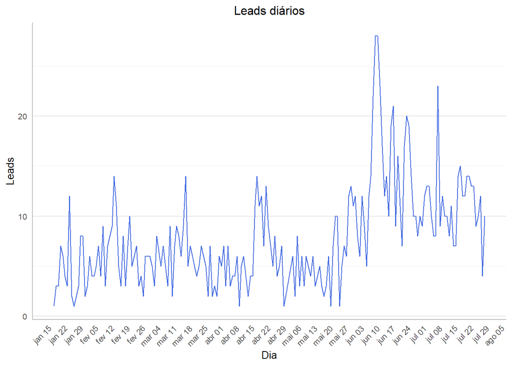

```r
dataset %>%
  group_by(Date) %>%
  summarise(leads = n()) %>%
  ggplot(aes(Date, leads)) +
  geom_line(color = "royalblue", linewidth = 0.5) +
  labs(title = "Leads diários",
       x = "Dia",
       y = "Leads") +
  scale_x_date(date_labels = "%b %d", date_breaks = "1 week") +
  my_theme + no_legend +
  theme(
    axis.text.x = element_text(angle = 45, hjust = 1),
    panel.grid.major.x = element_blank(),
    panel.grid.minor.x = element_blank()
  )
```

#### Leads por anúncio

Vamos analisar a quantidade de leads por anúncio.

```r
data_sum <- dataset %>%
  group_by(Listing) %>%
  summarise(
    date_min = min(Date),
    date_max = max(Date),
    days = if_else(date_min == date_max, 1, as.numeric(difftime(date_max, date_min, units = "days"))),
    leads = n(),
    leads_day = leads / if_else(days == 0, 1, days)
  )

kable(head(data_sum))
```

| Listing | date_min | date_max | days | leads | leads_day |
| --- | --- | --- | --- | --- | --- |
| 00OPP2 | 2024-03-10 | 2024-03-10 | 1 | 1 | 1.0000000 |
| 00SLR7 | 2024-06-29 | 2024-06-29 | 1 | 1 | 1.0000000 |
| 00TPRF | 2024-06-23 | 2024-06-23 | 1 | 1 | 1.0000000 |
| 02NTL4 | 2024-04-20 | 2024-06-10 | 51 | 3 | 0.0588235 |
| 04NM7E | 2024-07-19 | 2024-07-19 | 1 | 1 | 1.0000000 |
| 05MEKS | 2024-01-27 | 2024-01-27 | 1 | 1 | 1.0000000 |

##### Estatísticas descritivas

```r
sumtable(data_sum, add.median = T)
```

Summary Statistics

| Variable | N | Mean | Std. Dev. | Min | Pctl. 25 | Pctl. 50 | Pctl. 75 | Max |
| --- | --- | --- | --- | --- | --- | --- | --- | --- |
| days | 818 | 14 | 27 | 1 | 1 | 1 | 13 | 171 |
| leads | 818 | 1.8 | 1.7 | 1 | 1 | 1 | 2 | 15 |
| leads_day | 818 | 0.75 | 0.45 | 0.018 | 0.23 | 1 | 1 | 3 |

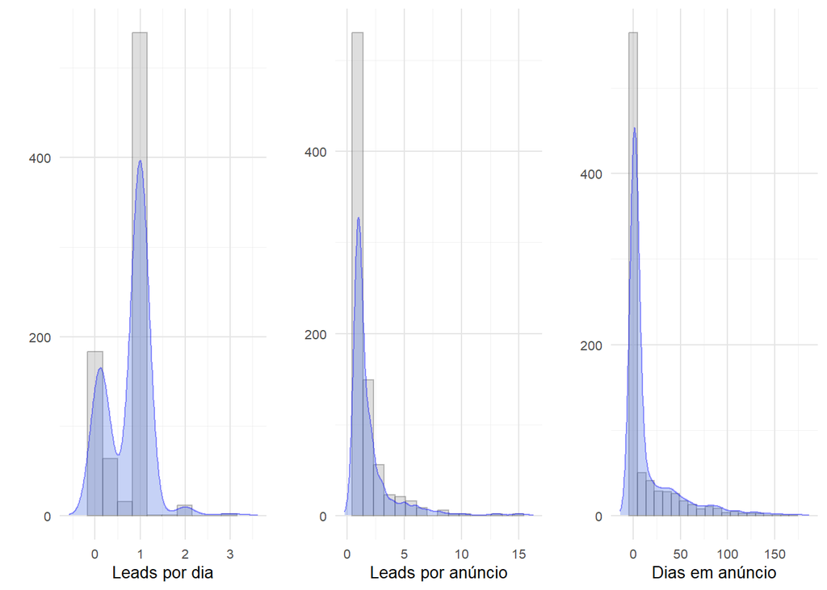

```r
themed_hist <- function(.plot, bins, label, bandwidth = 0.5, scale = 500) {
  .plot +
    geom_histogram(bins = bins, fill = "gray", color = adjustcolor("gray20", alpha.f = 0.3), alpha = 0.5) +
    # geom_density(fill = "blue", alpha = 0.2) +
    geom_density_ridges(aes(y = 1),
                        bandwidth = bandwidth,
                        scale = scale,
                        fill = "royalblue",
                        color = adjustcolor("blue", alpha.f = 0.4),
                        alpha = 0.3) +
    labs(x = label,
         y = "") +
    my_theme + no_legend + no_grid + no_axis
}

grid.arrange(
  ggplot(data_sum, aes(leads_day)) %>% themed_hist(10, "Leads por dia", 0.2, 300),
  ggplot(data_sum, aes(leads)) %>% themed_hist(16, "Leads por anúncio", 0.4),
  ggplot(data_sum, aes(days)) %>% themed_hist(20, "Dias em anúncio", 5, 8000),
  ncol = 3
)
```

**Dúvida**: Que tipo de distribuição poderia ser usada para modelar esses dados? Gamma? Betha? Weibull?

[figure not shown]

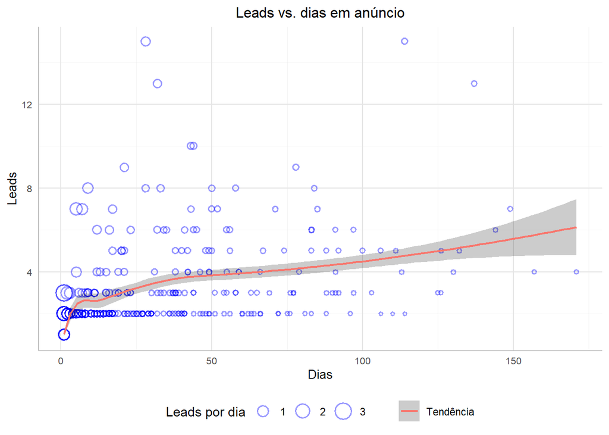

```r
data_sum %>%
  ggplot() +
  geom_point(aes(days, leads, size = leads_day),
             shape = 21,
             alpha = 0.4,
             stroke = 0.8,
             colour = "blue") +
  geom_smooth(aes(days, leads, col = "Tendência"),
              formula = 'y ~ x',
              method = "loess",
              linewidth = 0.8,
              fill = "black",
              alpha = 0.2) +
  labs(title = "Leads vs. dias em anúncio",
       x = "Dias",
       y = "Leads",
       size = "Leads por dia",
       col = "") +
  my_theme +
  theme(legend.position = "bottom")
```

A relação entre `Leads` e `Dias` parece ser positiva, indicando que anúncios mais longos tendem a ter mais leads. No entanto, a relação não é linear, sugerindo que a taxa de crescimento diminui com o tempo. Entende-se que isso se deve ao aumento da probabilidade do anúncio ser observado por um comprador potencial.

Já a relação entre `Leads por dia` e `Dias` parece ser negativa, indicando que anúncios mais longos tendem a ter menos leads por dia. Isso pode ser explicado pelo fato de que anúncios que duram mais possuem menos características atrativas para os compradores potenciais.

**Nota**: a partir disso nota-se um novo problema, estamos vendo apenas anúncios que tiveram leads, e aqueles que não tiveram?